# Question

Quadratic polynomial $p$ is defined below in standard form.
$$p(x)~=~x^{2}+{10}x+{34}$$

By [completing the square](https://en.wikipedia.org/wiki/Completing_the_square), you can rewrite the quadratic polynomial in vertex form:

$$p(x) = a(x-h)^2+k$$

where $(h,k)$ is the vertex of the parabola (and $a$ is the same as the quadratic coefficient, which equals 1 in this problem.)

Determine the coordinates of the vertex of quadratic polynomial $p$.

- $h=$ ##ANSWER1##
- $k=$ ##ANSWER2##

## Answerlist

- -10
- -9
- -8
- -7
- -6
- -5
- -4
- -3
- -2
- -1
- 0
- 1
- 2
- 3
- 4
- 5
- 6
- 7
- 8
- 9
- 10
- -10
- -9
- -8
- -7
- -6
- -5
- -4
- -3
- -2
- -1
- 0
- 1
- 2
- 3
- 4
- 5
- 6
- 7
- 8
- 9
- 10

# Solution

Helpful video: Khan academy

Here is a list of some perfect squares:

$$\begin{align*}
(x-5)^2 ~&=~ x^2-10x+25 \\
(x-4)^2 ~&=~ x^2-8x+16 \\
(x-3)^2 ~&=~ x^2-6x+9 \\
(x-2)^2 ~&=~ x^2-4x+4 \\
(x-1)^2 ~&=~ x^2-2x+1 \\
(x+1)^2 ~&=~ x^2+2x+1 \\
(x+2)^2 ~&=~ x^2+4x+4 \\
(x+3)^2 ~&=~ x^2+6x+9 \\
(x+4)^2 ~&=~ x^2+8x+16 \\
(x+5)^2 ~&=~ x^2+10x+25
\end{align*}$$

Notice that every perfect square in standard form has the form $(x+j)^2~=~x^2+2jx+j^2$.

We are given $p(x)~=~x^{2}+{10}x+{34}$. We can show that since our quadratic coefficient is 1 and our linear coefficient is 10, we just need to square half of 10 to “complete the square”.

$$\left(\frac{10}{2}\right)^2 ~=~
\left(5\right)^2 ~=~ 25$$

We then add and subtract this amount to the polynomial…

$$p(x) ~=~
x^{2}+{10}x+{25}+{34}-{25}$$

Notice the first three terms are a perfect square. Rewrite them in factored form.

$$p(x) ~=~
\left(x+{5}\right)^2+{34}-{25}$$

Combine the constants.

$$p(x) ~=~
\left(x+{5}\right)^2+{9}$$

And so:

$$h = -5$$
$$k = 9$$

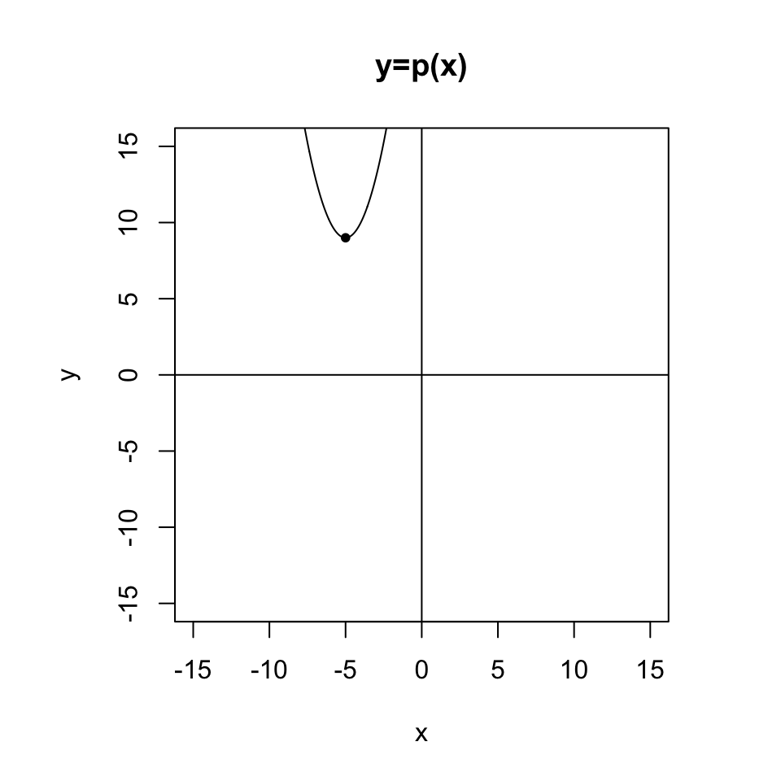

# Meta-information

extype: cloze exclozetype: schoice|schoice exsolution: 000001000000000000000|000000000000000000010 exname: complete_the_square